# ANOVA Bifatorial

```r
modelo <- lmerTest::lmer(NumErros ~ Alcool*Cafeina + (1|UE),
                         data=Dados)
```

```
boundary (singular) fit: see help('isSingular')
```

```r
cat("\nANOVA")
```

```
ANOVA
```

```r
print(anv <- car::Anova(modelo,test.statistic="F"))
```

```
Analysis of Deviance Table (Type II Wald F tests with Kenward-Roger df)

Response: NumErros
                     F Df Df.res    Pr(>F)
Alcool         47.6924  1     22 6.191e-07 ***
Cafeina         0.1678  1     22   0.68601
Alcool:Cafeina  6.0420  1     22   0.02231 *
---
Signif. codes:  0 '***' 0.001 '**' 0.01 '*' 0.05 '.' 0.1 ' ' 1
```

```r
print(summary(modelo, correl=FALSE))
```

```
Linear mixed model fit by REML. t-tests use Satterthwaite's method [
lmerModLmerTest]
Formula: NumErros ~ Alcool * Cafeina + (1 | UE)
   Data: Dados

REML criterion at convergence: 275.2

Scaled residuals:
     Min       1Q   Median       3Q      Max
-2.19632 -0.48572  0.02534  0.76449  1.99358

Random effects:
 Groups   Name        Variance Std.Dev.
 UE       (Intercept)  0.00    0.000
 Residual             24.33    4.932
Number of obs: 48, groups:  UE, 24

Fixed effects:
                       Estimate Std. Error     df t value Pr(>|t|)
(Intercept)               7.917      1.424 44.000   5.560 1.49e-06 ***
AlcoolComA               13.333      2.014 44.000   6.621 4.11e-08 ***
CafeinaComC               2.917      2.014 44.000   1.448    0.155
AlcoolComA:CafeinaComC   -7.000      2.848 44.000  -2.458    0.018 *
---
Signif. codes:  0 '***' 0.001 '**' 0.01 '*' 0.05 '.' 0.1 ' ' 1
optimizer (nloptwrap) convergence code: 0 (OK)
boundary (singular) fit: see help('isSingular')
```

```r
cat("\nEffect size analysis")
```

```
Effect size analysis
```

```r
eta2g <- as.numeric(MuMIn::r.squaredGLMM(modelo)[1])
cat("\nTamanho de efeito: eta^2 omnibus =", eta2g)
```

```
Tamanho de efeito: eta^2 omnibus = 0.5342025
```

```r
es <- effectsize::interpret_eta_squared(eta2g)
names(es) <- c("Tamanho de efeito omnibus: estimativa pontual")
print(es)
```

```
Tamanho de efeito omnibus: estimativa pontual
                                      "large"
(Rules: field2013)
```

```r
eta2 <- effectsize::eta_squared(anv)
print(eta2, digits = 6)
```

```
# Effect Size for ANOVA (Type II)

Parameter      | Eta2 (partial) |               95% CI
------------------------------------------------------
Alcool         |       0.684327 | [0.477568, 1.000000]
Cafeina        |       0.007571 | [0.000000, 1.000000]
Alcool:Cafeina |       0.215464 | [0.019433, 1.000000]

- One-sided CIs: upper bound fixed at [1.000000].
```

```r
eta2 <- effectsize::eta_squared(anv,
                                partial=FALSE,
                                generalized=FALSE,
                                ci=1-alfa/3,
                                alternative="two.sided",
                                verbose=TRUE)
eta2$interpret <- effectsize::interpret_eta_squared(eta2$Eta2)
print(eta2, digits=6)
```

```
# Effect Size for ANOVA (Type II)

Parameter      | Eta2 (partial) |          98.3333% CI |  interpret
-------------------------------------------------------------------
Alcool         |       0.684327 | [0.351068, 0.829263] |      large
Cafeina        |       0.007571 | [0.000000, 0.015304] | very small
Alcool:Cafeina |       0.215464 | [0.000000, 0.530612] |      large
```

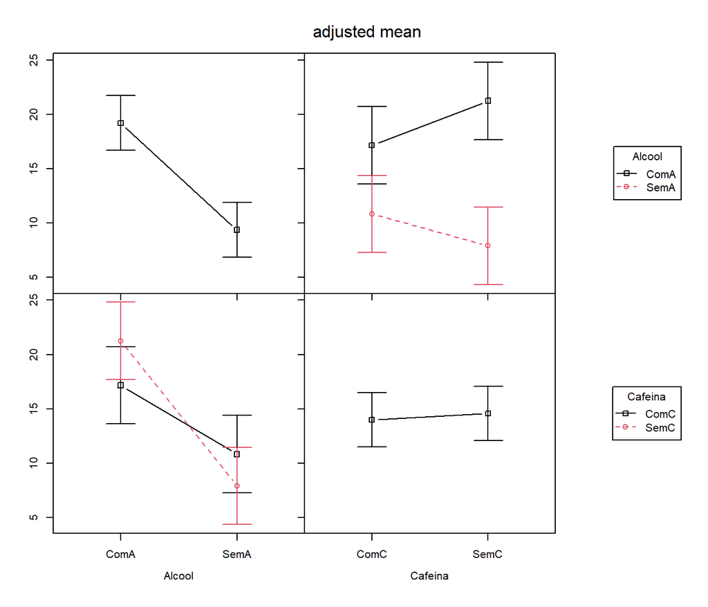

```r
# Grafico de perfil de médias
o.par <- par()
fit.means <- phia::interactionMeans(modelo)
plot(fit.means,
     errorbar=paste0("ci",
                     round((1-alfaBonf)*100,4)),
     abbrev.levels=TRUE)
par(o.par)
```

```
NOTE: Cafeina is not a high-order term in the model
```

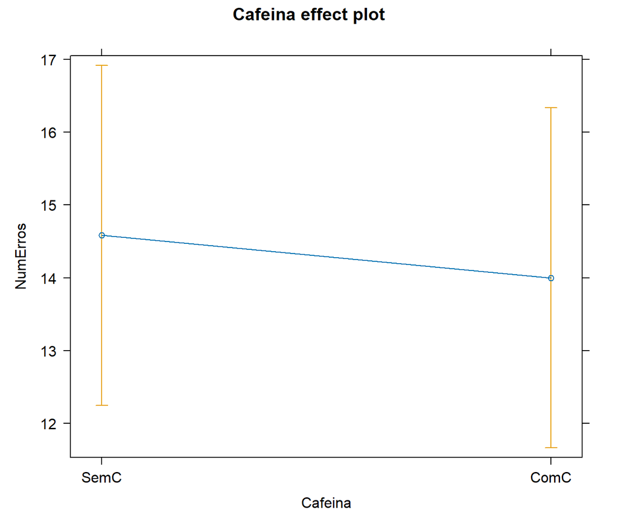

```r
plot(effects::effect(c("Cafeina"), modelo, confidence.level=1-alfa/
                       length(unique(Dados$Cafeina))),
     ci.style = "bars")
```

```
NOTE: Alcool is not a high-order term in the model
```

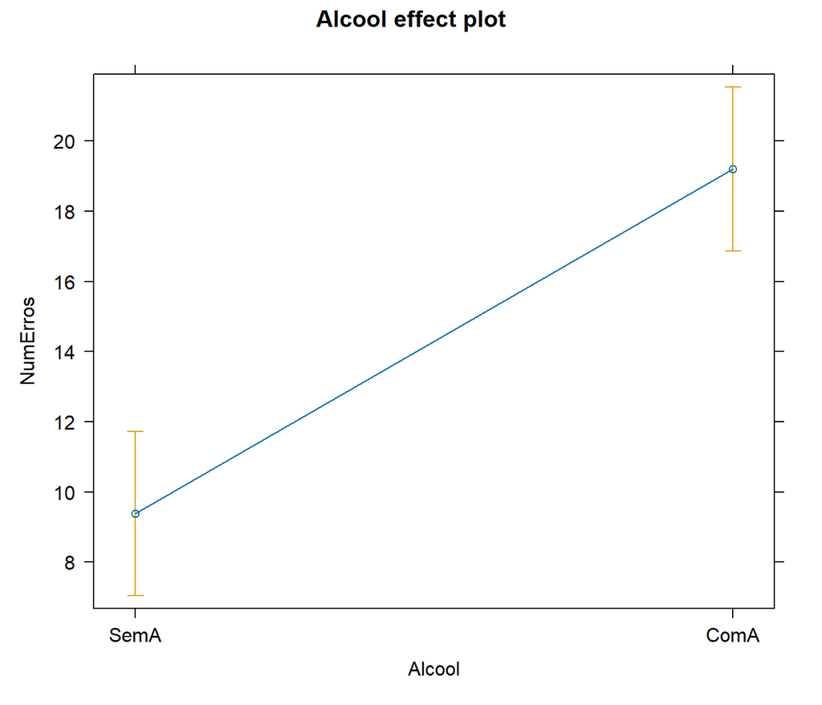

```r
plot(effects::effect(c("Alcool"), modelo, confidence.level=1-alfa/
                       length(unique(Dados$Alcool))),
     ci.style = "bars")
```

```
NOTE: CafeinaAlcool does not appear in the model
```

```
NOTE: CafeinaAlcool is not a high-order term in the model
```

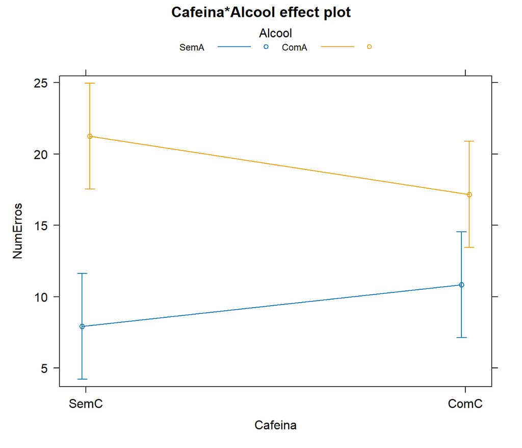

```r
plot(effects::effect(c("Cafeina", "Alcool"), modelo,
                     confidence.level=1-alfaBonf),
     multiline = TRUE, ci.style = "bars")
```

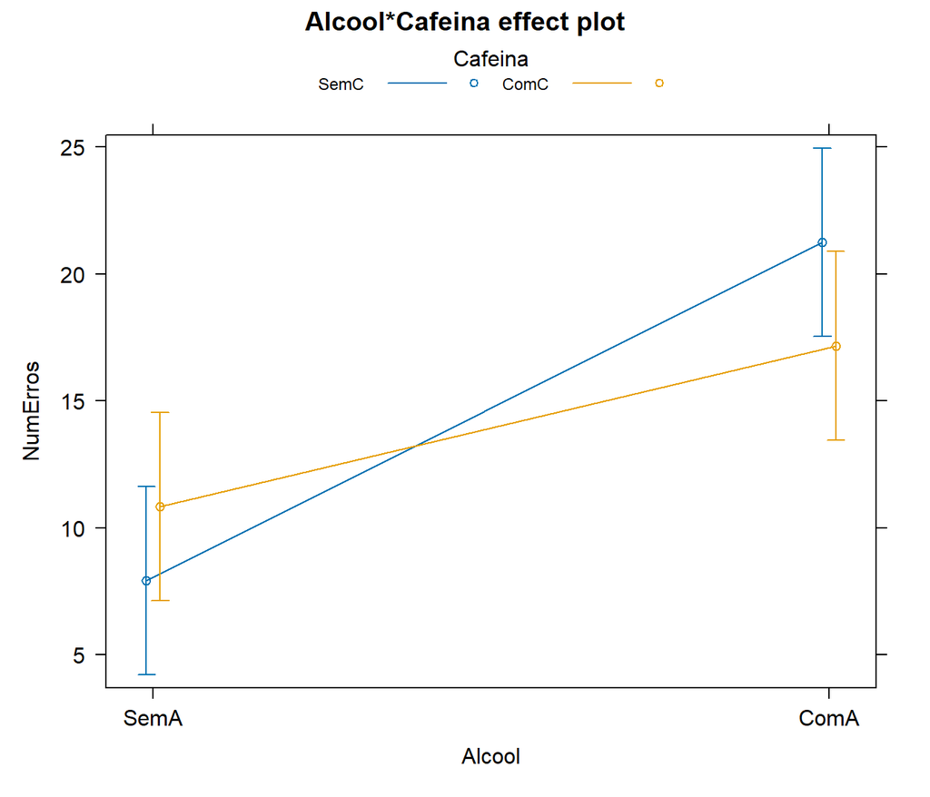

```r
plot(effects::allEffects(modelo,
                         confidence.level=1-alfaBonf),
     multiline = TRUE, ci.style = "bars")
```

```r
cat("\nSimple main effects: global")
```

```
Simple main effects: global
```

```r
cat("\n\t- Alcool at Cafeina levels\n")
```

```
    - Alcool at Cafeina levels
```

```r
print(phia::testInteractions(modelo, fixed="Cafeina", across="Alcool"))
```

```
Chisq Test:
P-value adjustment method: holm
        Value     SE Df  Chisq Pr(>Chisq)
SemC -13.3333 2.0137  1 43.842  7.118e-11 ***
ComC  -6.3333 2.0137  1  9.892    0.00166 **
---
Signif. codes:  0 '***' 0.001 '**' 0.01 '*' 0.05 '.' 0.1 ' ' 1
```

```r
cat("\n\t- Cafeina at Alcool levels\n")
```

```
    - Cafeina at Alcool levels
```

```r
print(phia::testInteractions(modelo, fixed="Alcool", across="Cafeina"))
```

```
Chisq Test:
P-value adjustment method: holm
       Value     SE Df  Chisq Pr(>Chisq)
SemA -2.9167 2.0137  1 2.0979    0.14750
ComA  4.0833 2.0137  1 4.1119    0.08516 .
---
Signif. codes:  0 '***' 0.001 '**' 0.01 '*' 0.05 '.' 0.1 ' ' 1
```

```r
cat("\nPost hoc tests")
```

```
Post hoc tests
```

```r
cat("\n\tAlcool:Cafeina")
```

```
    Alcool:Cafeina
```

```r
EMM.AC <- emmeans::emmeans(modelo,
                           specs=pairwise~"Alcool:Cafeina",
                           adjust="holm",
                           level=1-alfa,
                           lmer.df="satterthwaite",
                           lmerTest.limit=nrow(Dados))
print(summary(EMM.AC$emmeans))
```

```
 Alcool Cafeina emmean   SE df lower.CL upper.CL
 SemA   SemC      7.92 1.42 44     5.05     10.8
 ComA   SemC     21.25 1.42 44    18.38     24.1
 SemA   ComC     10.83 1.42 44     7.96     13.7
 ComA   ComC     17.17 1.42 44    14.30     20.0

Degrees-of-freedom method: satterthwaite
Confidence level used: 0.95
```

```r
print(summary(EMM.AC$contrasts, infer=TRUE))
```

```
 contrast              estimate   SE df lower.CL upper.CL t.ratio p.value
 SemA SemC - ComA SemC   -13.33 2.01 44   -18.90    -7.77  -6.621  <.0001
 SemA SemC - SemA ComC    -2.92 2.01 44    -8.48     2.65  -1.448  0.1546
 SemA SemC - ComA ComC    -9.25 2.01 44   -14.81    -3.69  -4.594  0.0001
 ComA SemC - SemA ComC    10.42 2.01 44     4.85    15.98   5.173  <.0001
 ComA SemC - ComA ComC     4.08 2.01 44    -1.48     9.65   2.028  0.0973
 SemA ComC - ComA ComC    -6.33 2.01 44   -11.90    -0.77  -3.145  0.0089

Degrees-of-freedom method: satterthwaite
Confidence level used: 0.95
Conf-level adjustment: bonferroni method for 6 estimates
P value adjustment: holm method for 6 tests
```

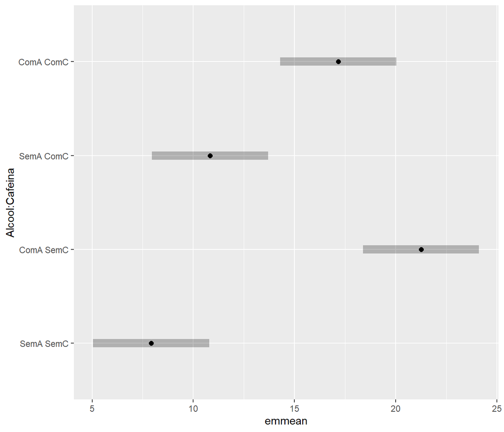

```r
print(plot(EMM.AC$emmeans,
           colors="black"))
```

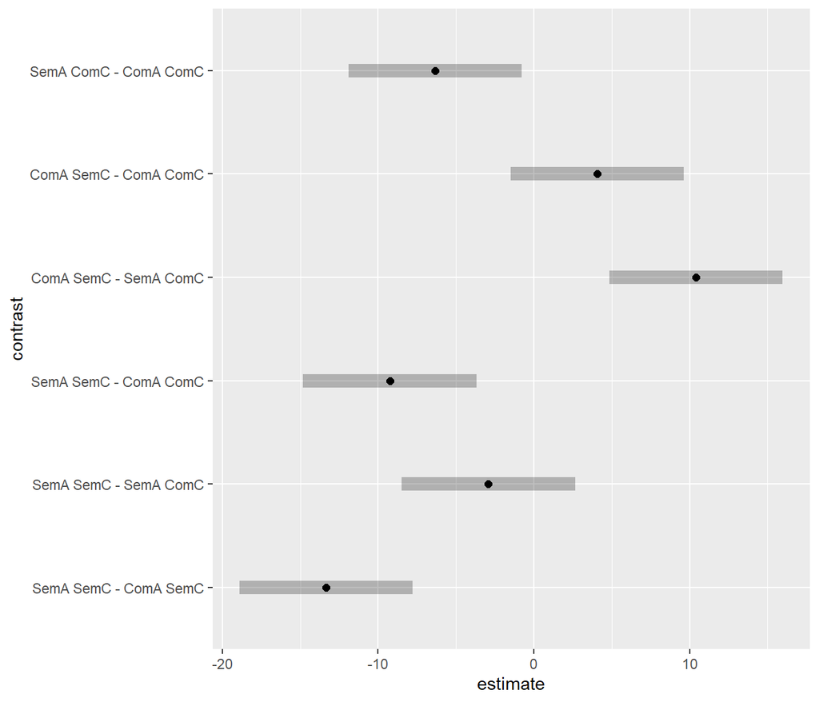

```r
print(plot(EMM.AC$contrasts,
           colors="black"))
```

```r
print(multcomp::cld(object=EMM.AC$emmeans,
                    level=1-alfa,
                    adjust="holm",
                    Letters=letters,
                    alpha=alfa))
```

```
 Alcool Cafeina emmean   SE df lower.CL upper.CL .group
 SemA   SemC      7.92 1.42 44     4.21     11.6  a
 SemA   ComC     10.83 1.42 44     7.12     14.5  a
 ComA   ComC     17.17 1.42 44    13.46     20.9   b
 ComA   SemC     21.25 1.42 44    17.54     25.0   b

Degrees-of-freedom method: satterthwaite
Confidence level used: 0.95
Conf-level adjustment: bonferroni method for 4 estimates
P value adjustment: holm method for 6 tests
significance level used: alpha = 0.05
NOTE: If two or more means share the same grouping symbol,
      then we cannot show them to be different.
      But we also did not show them to be the same.
```

```r
cat("\n\tAlcool")
```

```
    Alcool
```

```r
EMM.A <- emmeans::emmeans(modelo,
                          specs=pairwise~"Alcool",
                          adjust="holm",
                          level=1-alfa,
                          lmer.df="satterthwaite",
                          lmerTest.limit=nrow(Dados))
```

```
NOTE: Results may be misleading due to involvement in interactions
```

```r
print(summary(EMM.A$emmeans))
```

```
 Alcool emmean   SE df lower.CL upper.CL
 SemA     9.38 1.01 44     7.35     11.4
 ComA    19.21 1.01 44    17.18     21.2

Results are averaged over the levels of: Cafeina
Degrees-of-freedom method: satterthwaite
Confidence level used: 0.95
```

```r
print(summary(EMM.A$contrasts, infer=TRUE))
```

```
 contrast    estimate   SE df lower.CL upper.CL t.ratio p.value
 SemA - ComA    -9.83 1.42 44    -12.7    -6.96  -6.906  <.0001

Results are averaged over the levels of: Cafeina
Degrees-of-freedom method: satterthwaite
Confidence level used: 0.95
```

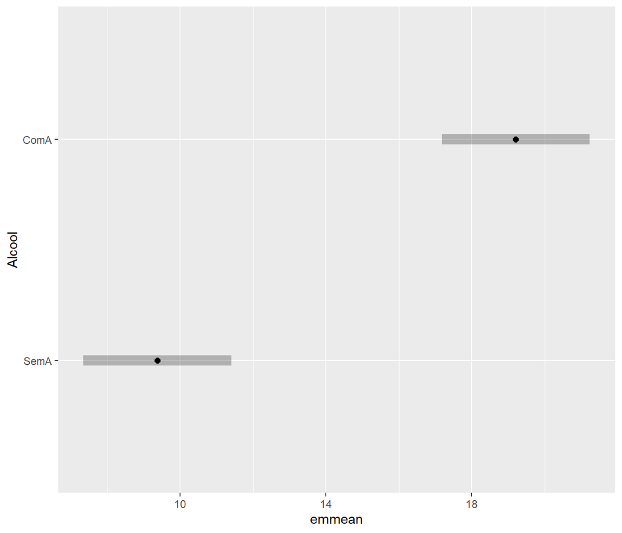

```r
print(plot(EMM.A$emmeans,
           colors="black"))
```

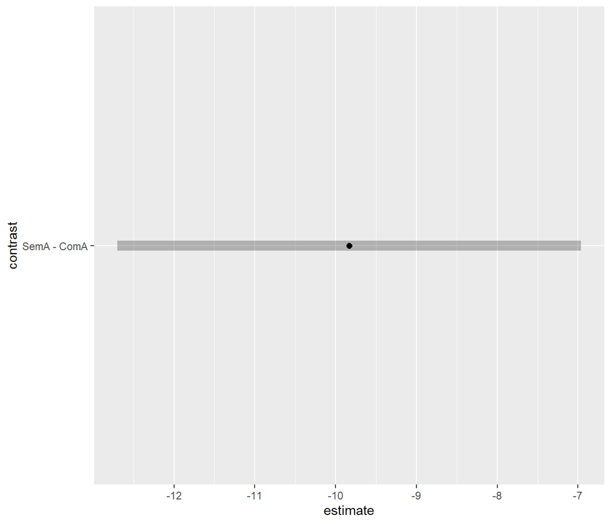

```r
print(plot(EMM.A$contrasts,
           colors="black"))
```

```r
print(multcomp::cld(object=EMM.A$emmeans,
                    level=1-alfa,
                    adjust="holm",
                    Letters=letters,
                    alpha=alfa))
```

```
 Alcool emmean   SE df lower.CL upper.CL .group
 SemA     9.38 1.01 44     7.04     11.7  a
 ComA    19.21 1.01 44    16.87     21.5   b

Results are averaged over the levels of: Cafeina
Degrees-of-freedom method: satterthwaite
Confidence level used: 0.95
Conf-level adjustment: bonferroni method for 2 estimates
significance level used: alpha = 0.05
NOTE: If two or more means share the same grouping symbol,
      then we cannot show them to be different.
      But we also did not show them to be the same.
```

```r
cat("\n\tCafeina")
```

```
    Cafeina
```

```r
EMM.C <- emmeans::emmeans(modelo,
                          specs=pairwise~"Cafeina",
                          adjust="holm",
                          level=1-alfa,
                          lmer.df="satterthwaite",
                          lmerTest.limit=nrow(Dados))
```

```
NOTE: Results may be misleading due to involvement in interactions
```

```r
print(summary(EMM.C$emmeans))
```

```
 Cafeina emmean   SE df lower.CL upper.CL
 SemC      14.6 1.01 44     12.6     16.6
 ComC      14.0 1.01 44     12.0     16.0

Results are averaged over the levels of: Alcool
Degrees-of-freedom method: satterthwaite
Confidence level used: 0.95
```

```r
print(summary(EMM.C$contrasts, infer=TRUE))
```

```
 contrast    estimate   SE df lower.CL upper.CL t.ratio p.value
 SemC - ComC    0.583 1.42 44    -2.29     3.45   0.410  0.6840

Results are averaged over the levels of: Alcool
Degrees-of-freedom method: satterthwaite
Confidence level used: 0.95
```

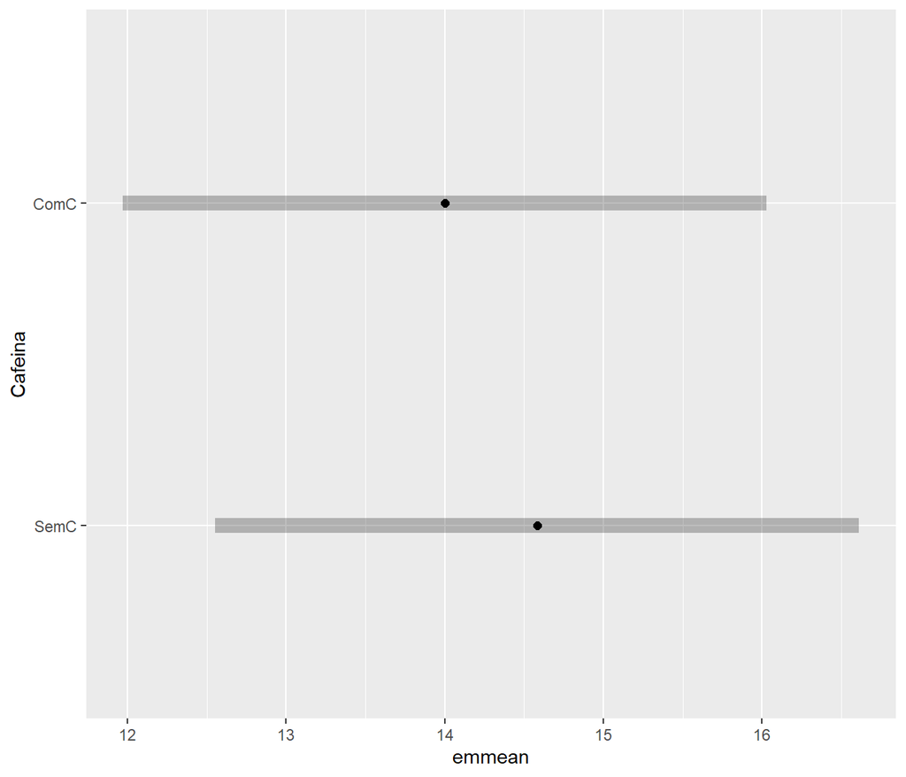

```r
print(plot(EMM.C$emmeans,
           colors="black"))
```

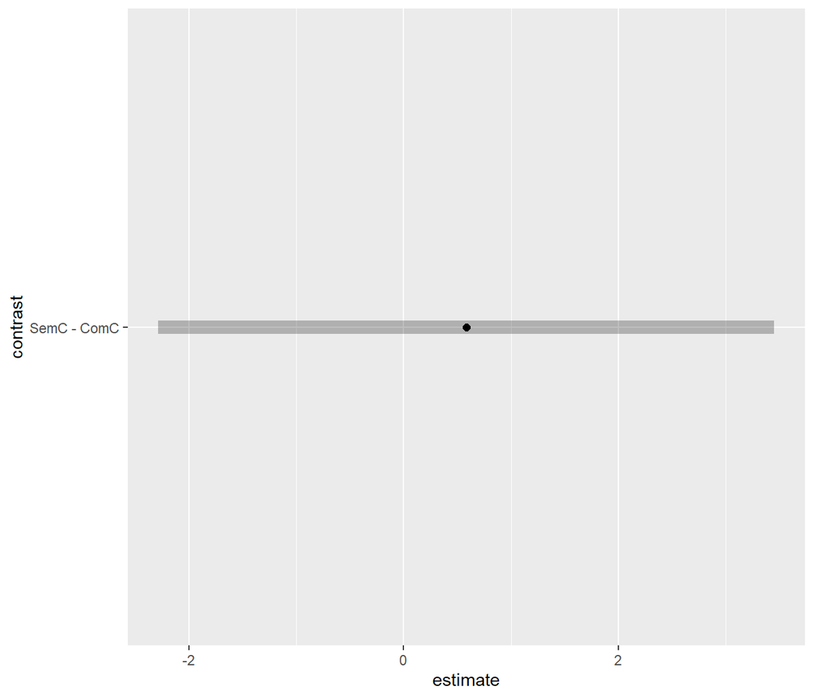

```r
print(plot(EMM.C$contrasts,
           colors="black"))
```

```r
print(multcomp::cld(object=EMM.C$emmeans,
                    level=1-alfa,
                    adjust="holm",
                    Letters=letters,
                    alpha=alfa))
```

```
 Cafeina emmean   SE df lower.CL upper.CL .group
 ComC      14.0 1.01 44     11.7     16.3  a
 SemC      14.6 1.01 44     12.2     16.9  a

Results are averaged over the levels of: Alcool
Degrees-of-freedom method: satterthwaite
Confidence level used: 0.95
Conf-level adjustment: bonferroni method for 2 estimates
significance level used: alpha = 0.05
NOTE: If two or more means share the same grouping symbol,
      then we cannot show them to be different.
      But we also did not show them to be the same.
```

Na ANOVA independente é requerido pelo menos duas observações em cada um dos tratamentos para testar efeito de interação.

Para ANOVA relacionada ou mista é requerido pelo menos uma observação de cada tratamento para testar efeito de interação.

Quando um modelo completo como

```r
modelo <- lm(NumErros ~ Alcool+Cafeina+Alcool:Cafeina,
             data=Dados)
```

não pode ser testado ou não se deseja testar, uma alternativa é usar um modelo de efeitos principais:

```r
modelo <- lm(NumErros ~ Alcool+Cafeina, data=Dados)
```

# ANOVA bifatorial para medidas repetidas ou mista com dados faltantes

| Para todos *Rscripts* de ANOVA bifatorial fornecidos neste capítulo, dados desbalanceados podem ser utilizados. |
| --- |

Por exemplo, trocando o arquivo de dados no caso de ANOVA bifatorial mista para `Cafeinaintra_Alcoolentre_D.rds`, a saída gerada por `demo_ANOVA_2f_indepAlcool_depCafeinaD.R` resulta em:

```r
Dados <- data.frame(readxl::read_excel("Cafeinaintra_Alcoolentre_D.xlsx"))
Dados$UE <- factor(Dados$UE)
Dados$Cafeina <- factor(Dados$Cafeina,
                        levels=c("SemC","ComC"))
Dados$Alcool <- factor(Dados$Alcool,
                       levels=c("SemA","ComA"))
saveRDS(Dados, "Cafeinaintra_Alcoolentre_D.rds")
```

```r
Dados <- readRDS("Cafeinaintra_Alcoolentre_D.rds")
print(ftable(Dados[,-2]))
```

```
          Cafeina SemC ComC
UE Alcool
1  SemA              0    1
   ComA              0    0
2  SemA              1    1
   ComA              0    0
3  SemA              1    1
   ComA              0    0
4  SemA              1    1
   ComA              0    0
5  SemA              1    1
   ComA              0    0
6  SemA              1    1
   ComA              0    0
7  SemA              1    1
   ComA              0    0
8  SemA              1    1
   ComA              0    0
9  SemA              1    1
   ComA              0    0
10 SemA              1    1
   ComA              0    0
11 SemA              1    1
   ComA              0    0
12 SemA              1    1
   ComA              0    0
13 SemA              0    0
   ComA              1    1
14 SemA              0    0
   ComA              1    1
15 SemA              0    0
   ComA              1    1
16 SemA              0    0
   ComA              1    1
17 SemA              0    0
   ComA              1    1
18 SemA              0    0
   ComA              1    1
19 SemA              0    0
   ComA              1    1
20 SemA              0    0
   ComA              1    1
21 SemA              0    0
   ComA              1    1
22 SemA              0    0
   ComA              1    1
23 SemA              0    0
   ComA              1    1
24 SemA              0    0
   ComA              1    1
```

```r
str(Dados)
```

```
'data.frame':   47 obs. of  4 variables:
 $ UE      : Factor w/ 24 levels "1","2","3","4",..: 1 2 2 3 3 4 4 5 5 6 ...
 $ NumErros: num  15 9 8 10 17 8 0 6 15 11 ...
 $ Alcool  : Factor w/ 2 levels "SemA","ComA": 1 1 1 1 1 1 1 1 1 1 ...
 $ Cafeina : Factor w/ 2 levels "SemC","ComC": 2 1 2 1 2 1 2 1 2 1 ...
```

```r
print.data.frame(Dados)
```

```
   UE NumErros Alcool Cafeina
1   1       15   SemA    ComC
2   2        9   SemA    SemC
3   2        8   SemA    ComC
4   3       10   SemA    SemC
5   3       17   SemA    ComC
6   4        8   SemA    SemC
7   4        0   SemA    ComC
8   5        6   SemA    SemC
9   5       15   SemA    ComC
10  6       11   SemA    SemC
11  6       11   SemA    ComC
12  7        2   SemA    SemC
13  7       11   SemA    ComC
14  8       11   SemA    SemC
```

[output cut: 33 more lines]

```r
print(summary(Dados))
```

```
       UE        NumErros      Alcool   Cafeina
 2      : 2   Min.   : 0.00   SemA:23   SemC:23
 3      : 2   1st Qu.:10.00   ComA:24   ComC:24
 4      : 2   Median :15.00
 5      : 2   Mean   :14.51
 6      : 2   3rd Qu.:19.50
 7      : 2   Max.   :28.00
 (Other):35
```

```r
print(xtabs(~Cafeina+Alcool, data=Dados))
```

```
       Alcool
Cafeina SemA ComA
   SemC   11   12
   ComC   12   12
```

```r
source("summarySEwithin2.R")
Dados <- readRDS("Cafeinaintra_Alcoolentre_D.rds")
alfa <- 0.05
print(ftable(Dados[,-2]))
```

```
          Cafeina SemC ComC
UE Alcool
1  SemA              0    1
   ComA              0    0
2  SemA              1    1
   ComA              0    0
3  SemA              1    1
   ComA              0    0
4  SemA              1    1
   ComA              0    0
5  SemA              1    1
   ComA              0    0
6  SemA              1    1
   ComA              0    0
7  SemA              1    1
   ComA              0    0
8  SemA              1    1
   ComA              0    0
9  SemA              1    1
   ComA              0    0
10 SemA              1    1
   ComA              0    0
11 SemA              1    1
   ComA              0    0
12 SemA              1    1
   ComA              0    0
13 SemA              0    0
   ComA              1    1
14 SemA              0    0
   ComA              1    1
15 SemA              0    0
   ComA              1    1
16 SemA              0    0
   ComA              1    1
17 SemA              0    0
   ComA              1    1
18 SemA              0    0
   ComA              1    1
19 SemA              0    0
   ComA              1    1
20 SemA              0    0
   ComA              1    1
21 SemA              0    0
   ComA              1    1
22 SemA              0    0
   ComA              1    1
23 SemA              0    0
   ComA              1    1
24 SemA              0    0
   ComA              1    1
```

```r
print(psych::describe(NumErros ~ Alcool*Cafeina,
                      data=Dados), digits=2)
```

```
 Descriptive statistics by group
Alcool: SemA
Cafeina: SemC
         vars  n mean   sd median trimmed  mad min max range  skew kurtosis
NumErros    1 11 8.27 3.23     10    8.67 1.48   2  11     9 -0.89    -0.87
           se
NumErros 0.97
------------------------------------------------------------
Alcool: ComA
Cafeina: SemC
         vars  n  mean   sd median trimmed  mad min max range skew kurtosis
NumErros    1 12 21.25 3.72   20.5    21.1 2.22  16  28    12 0.49    -1.04
           se
NumErros 1.07
------------------------------------------------------------
Alcool: SemA
Cafeina: ComC
         vars  n  mean   sd median trimmed  mad min max range skew kurtosis
NumErros    1 12 10.83 6.12     13    11.3 4.45   0  17    17 -0.7    -1.08
           se
NumErros 1.77
------------------------------------------------------------
Alcool: ComA
Cafeina: ComC
         vars  n  mean   sd median trimmed  mad min max range skew kurtosis
NumErros    1 12 17.17 5.92     15    16.9 6.67  10  27    17 0.41    -1.24
           se
NumErros 1.71
```

```r
alfaBonf <- alfa/(length(unique(Dados$Alcool))*
                  length(unique(Dados$Cafeina)))
ic <- summarySEwithin2(Dados,
                       measurevar="NumErros",
                       withinvars=c("Alcool","Cafeina"),
                       idvar="UE",
                       na.rm=TRUE,
                       conf.interval=1-alfaBonf)
print(ic)
```

```
  Alcool Cafeina  N  NumErros NumErrosNormed       sd       se       ci
1   ComA    ComC 12 17.166667       12.46897 4.468464 1.289934 3.845130
2   ComA    SemC 12 21.250000       16.55230 4.468464 1.289934 3.845130
3   SemA    ComC 12 10.833333       15.51064 4.334499 1.251262 3.729852
4   SemA    SemC 11  8.272727       13.41973 4.530034 1.365857 4.149805
```

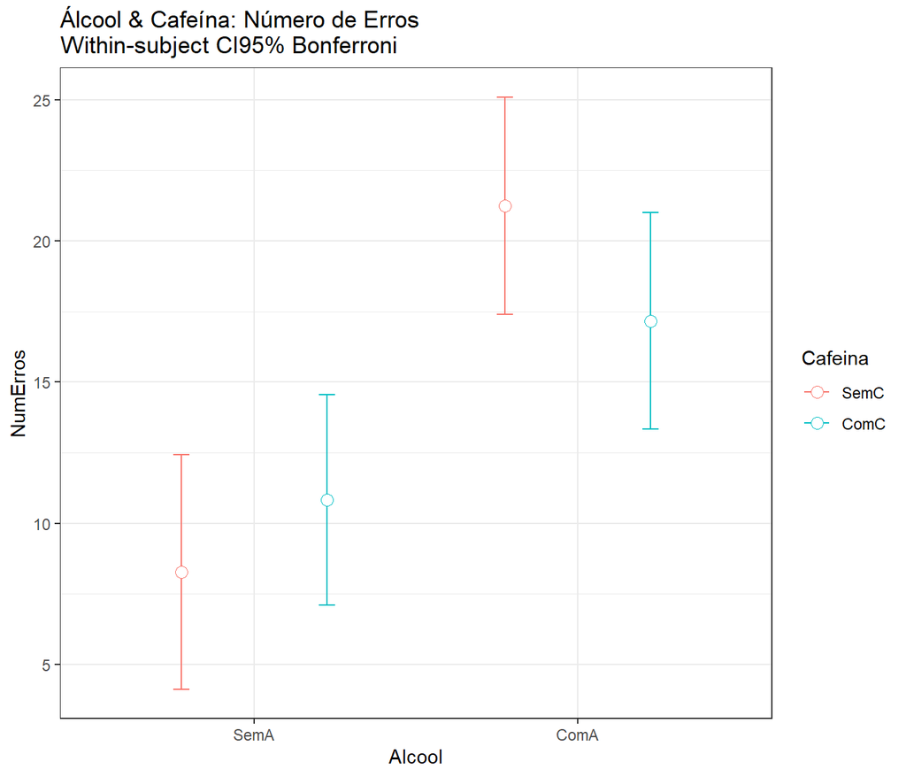

```r
grf <- ggplot2::ggplot(ic,
                       ggplot2::aes(x=Alcool,
                                    y=NumErros,
                                    colour=Cafeina)) +
  ggplot2::geom_errorbar(position=ggplot2::position_dodge(.9),
                         width=.1,
                         ggplot2::aes(ymin=NumErros-ci,
                                      ymax=NumErros+ci)) +
  ggplot2::geom_point(shape=21,
                      size=3,
                      fill="white",
                      position=ggplot2::position_dodge(.9)) +
  ggplot2::ylab("NumErros") +
  ggplot2::ggtitle("Álcool & Cafeína: Número de Erros\nWithin-subject CI95% Bonferroni") +
  ggplot2::theme_bw()
print(grf)
```

```r
modelo <- lmerTest::lmer(NumErros ~ Alcool*Cafeina + (1|UE),
                         data=Dados)
```

```
boundary (singular) fit: see help('isSingular')
```

```r
cat("\nANOVA")
```

```
ANOVA
```

```r
print(anv <- car::Anova(modelo,test.statistic="F"))
```

```
Analysis of Deviance Table (Type II Wald F tests with Kenward-Roger df)

Response: NumErros
                     F Df Df.res    Pr(>F)
Alcool         43.8255  1 21.732 1.249e-06 ***
Cafeina         0.3390  1 21.707   0.56643
Alcool:Cafeina  5.2725  1 21.730   0.03169 *
---
Signif. codes:  0 '***' 0.001 '**' 0.01 '*' 0.05 '.' 0.1 ' ' 1
```

```r
print(summary(modelo, correl=FALSE))
```

```
Linear mixed model fit by REML. t-tests use Satterthwaite's method [
lmerModLmerTest]
Formula: NumErros ~ Alcool * Cafeina + (1 | UE)
   Data: Dados

REML criterion at convergence: 269.4

Scaled residuals:
     Min       1Q   Median       3Q      Max
-2.18839 -0.45681  0.03367  0.76594  1.98638

Random effects:
 Groups   Name        Variance Std.Dev.
 UE       (Intercept)  0.00    0.00
 Residual             24.51    4.95
Number of obs: 47, groups:  UE, 24

Fixed effects:
                       Estimate Std. Error     df t value Pr(>|t|)
(Intercept)               8.273      1.493 43.000   5.543 1.69e-06 ***
AlcoolComA               12.977      2.066 43.000   6.280 1.43e-07 ***
CafeinaComC               2.561      2.066 43.000   1.239   0.2220
AlcoolComA:CafeinaComC   -6.644      2.890 43.000  -2.299   0.0264 *
---
Signif. codes:  0 '***' 0.001 '**' 0.01 '*' 0.05 '.' 0.1 ' ' 1
optimizer (nloptwrap) convergence code: 0 (OK)
boundary (singular) fit: see help('isSingular')
```

```r
cat("\nEffect size analysis")
```

```
Effect size analysis
```

```r
eta2g <- as.numeric(MuMIn::r.squaredGLMM(modelo)[1])
cat("\nTamanho de efeito: eta^2 omnibus =", eta2g)
```

```
Tamanho de efeito: eta^2 omnibus = 0.5197455
```

```r
es <- effectsize::interpret_eta_squared(eta2g)
names(es) <- c("Tamanho de efeito omnibus: estimativa pontual")
print(es)
```

```
Tamanho de efeito omnibus: estimativa pontual
                                      "large"
(Rules: field2013)
```

```r
eta2 <- effectsize::eta_squared(anv)
print(eta2, digits = 6)
```

```
# Effect Size for ANOVA (Type II)

Parameter      | Eta2 (partial) |               95% CI
------------------------------------------------------
Alcool         |       0.668501 | [0.453027, 1.000000]
Cafeina        |       0.015375 | [0.000000, 1.000000]
Alcool:Cafeina |       0.195259 | [0.010589, 1.000000]

- One-sided CIs: upper bound fixed at [1.000000].
```

```r
eta2 <- effectsize::eta_squared(anv,
                                partial=FALSE,
                                generalized=FALSE,
                                ci=1-alfa/3,
                                alternative="two.sided",
                                verbose=TRUE)
eta2$interpret <- effectsize::interpret_eta_squared(eta2$Eta2)
print(eta2, digits=6)
```

```
# Effect Size for ANOVA (Type II)

Parameter      | Eta2 (partial) |          98.3333% CI | interpret
------------------------------------------------------------------
Alcool         |       0.668501 | [0.323652, 0.821081] |     large
Cafeina        |       0.015375 | [0.000000, 0.288919] |     small
Alcool:Cafeina |       0.195259 | [0.000000, 0.515452] |     large
```

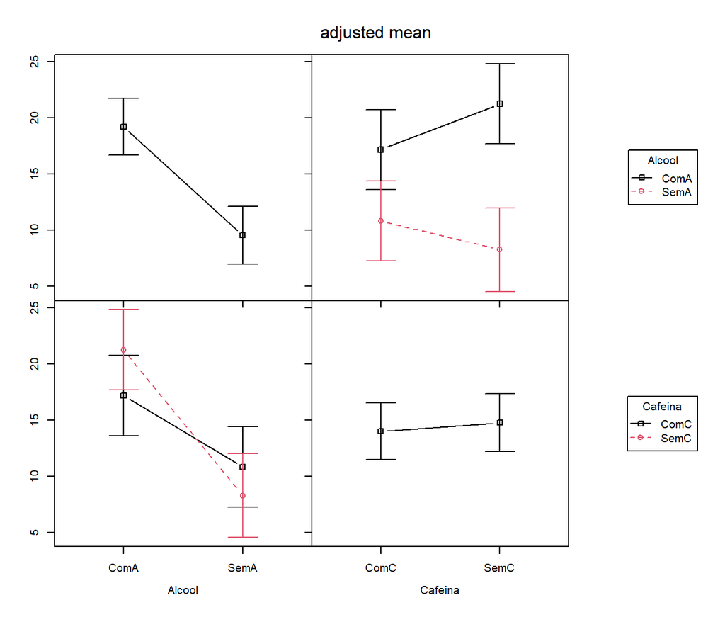

```r
# Grafico de perfil de médias
o.par <- par()
fit.means <- phia::interactionMeans(modelo)
plot(fit.means,
     errorbar=paste0("ci",
                     round((1-alfaBonf)*100,4)),
     abbrev.levels=TRUE)
par(o.par)
```

```
NOTE: Cafeina is not a high-order term in the model
```

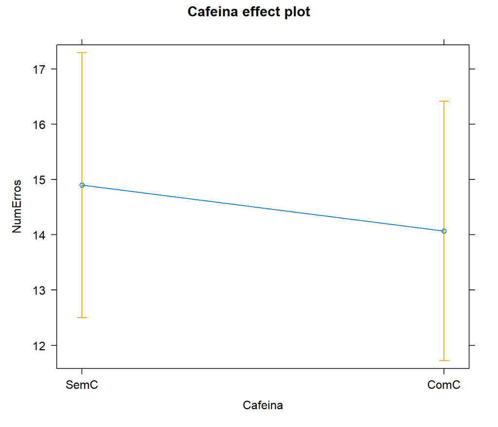

```r
plot(effects::effect(c("Cafeina"), modelo, confidence.level=1-alfa/
                       length(unique(Dados$Cafeina))),
     ci.style = "bars")
```

```
NOTE: Alcool is not a high-order term in the model
```

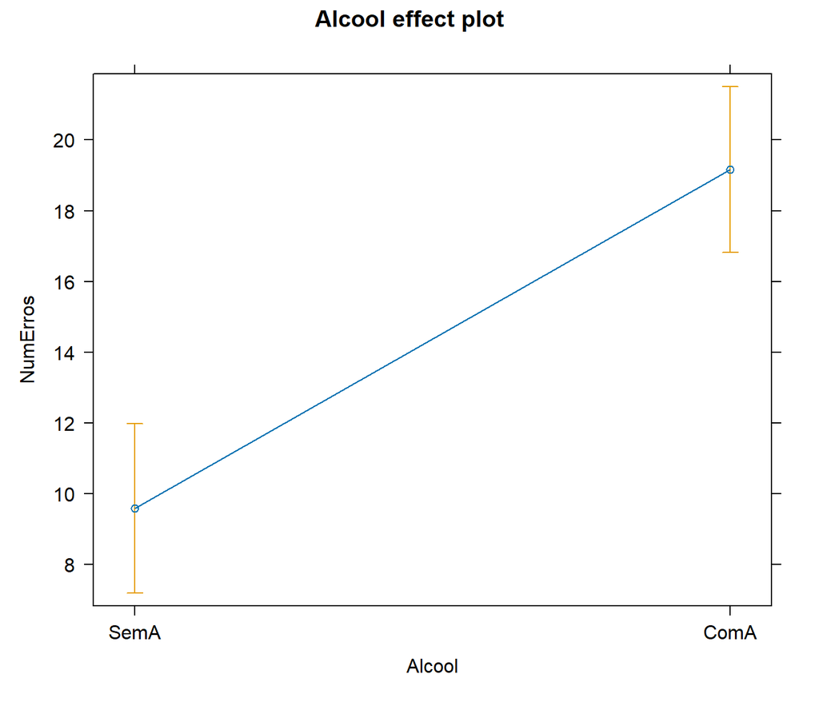

```r
plot(effects::effect(c("Alcool"), modelo, confidence.level=1-alfa/
                       length(unique(Dados$Alcool))),
     ci.style = "bars")
```

```
NOTE: CafeinaAlcool does not appear in the model
```

```
NOTE: CafeinaAlcool is not a high-order term in the model
```

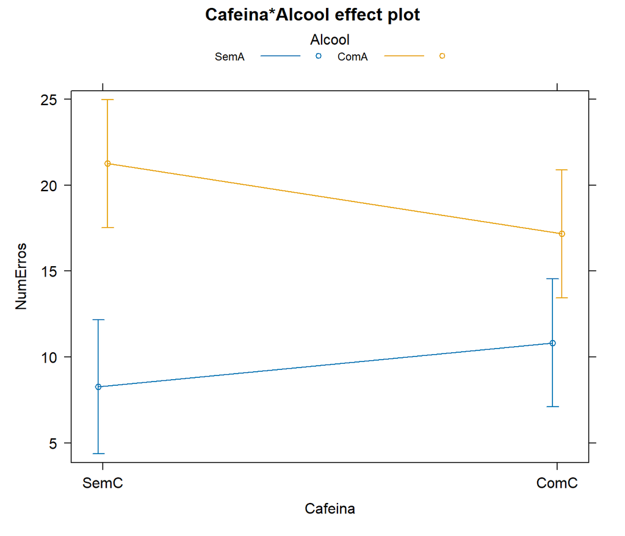

```r
plot(effects::effect(c("Cafeina", "Alcool"), modelo,
                     confidence.level=1-alfaBonf),
     multiline = TRUE, ci.style = "bars")
```

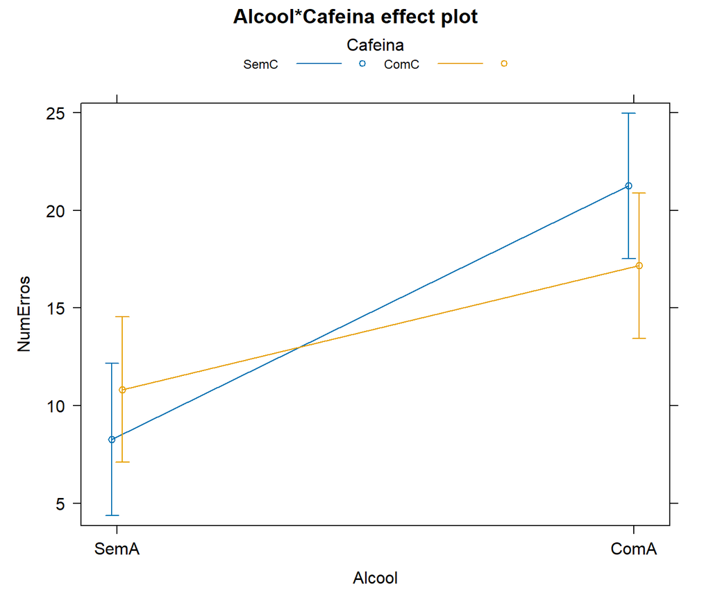

```r
plot(effects::allEffects(modelo,
                         confidence.level=1-alfaBonf),
     multiline = TRUE, ci.style = "bars")
```

```r
cat("\nSimple main effects: global")
```

```
Simple main effects: global
```

```r
cat("\n\t- Alcool at Cafeina levels\n")
```

```
    - Alcool at Cafeina levels
```

```r
print(phia::testInteractions(modelo, fixed="Cafeina", across="Alcool"))
```

```
Chisq Test:
P-value adjustment method: holm
        Value     SE Df   Chisq Pr(>Chisq)
SemC -12.9773 2.0664  1 39.4401  6.766e-10 ***
ComC  -6.3333 2.0210  1  9.8207   0.001726 **
---
Signif. codes:  0 '***' 0.001 '**' 0.01 '*' 0.05 '.' 0.1 ' ' 1
```

```r
cat("\n\t- Cafeina at Alcool levels\n")
```

```
    - Cafeina at Alcool levels
```

```r
print(phia::testInteractions(modelo, fixed="Alcool", across="Cafeina"))
```

```
Chisq Test:
P-value adjustment method: holm
       Value     SE Df  Chisq Pr(>Chisq)
SemA -2.5606 2.0664  1 1.5355    0.21529
ComA  4.0833 2.0210  1 4.0823    0.08667 .
---
Signif. codes:  0 '***' 0.001 '**' 0.01 '*' 0.05 '.' 0.1 ' ' 1
```

```r
cat("\nPost hoc tests")
```

```
Post hoc tests
```

```r
cat("\n\tAlcool:Cafeina")
```

```
    Alcool:Cafeina
```

```r
EMM.AC <- emmeans::emmeans(modelo,
                           specs=pairwise~"Alcool:Cafeina",
                           adjust="holm",
                           level=1-alfa,
                           lmer.df="satterthwaite",
                           lmerTest.limit=nrow(Dados))
print(summary(EMM.AC$emmeans))
```

```
 Alcool Cafeina emmean   SE df lower.CL upper.CL
 SemA   SemC      8.27 1.49 43     5.26     11.3
 ComA   SemC     21.25 1.43 43    18.37     24.1
 SemA   ComC     10.83 1.43 43     7.95     13.7
 ComA   ComC     17.17 1.43 43    14.28     20.0

Degrees-of-freedom method: satterthwaite
Confidence level used: 0.95
```

```r
print(summary(EMM.AC$contrasts, infer=TRUE))
```

```
 contrast              estimate   SE df lower.CL upper.CL t.ratio p.value
 SemA SemC - ComA SemC   -12.98 2.07 43   -18.69   -7.262  -6.280  <.0001
 SemA SemC - SemA ComC    -2.56 2.07 43    -8.28    3.155  -1.239  0.2220
 SemA SemC - ComA ComC    -8.89 2.07 43   -14.61   -3.179  -4.304  0.0004
 ComA SemC - SemA ComC    10.42 2.02 43     4.83   16.006   5.154  <.0001
 ComA SemC - ComA ComC     4.08 2.02 43    -1.51    9.673   2.020  0.0992
 SemA ComC - ComA ComC    -6.33 2.02 43   -11.92   -0.744  -3.134  0.0093

Degrees-of-freedom method: satterthwaite
Confidence level used: 0.95
Conf-level adjustment: bonferroni method for 6 estimates
P value adjustment: holm method for 6 tests
```

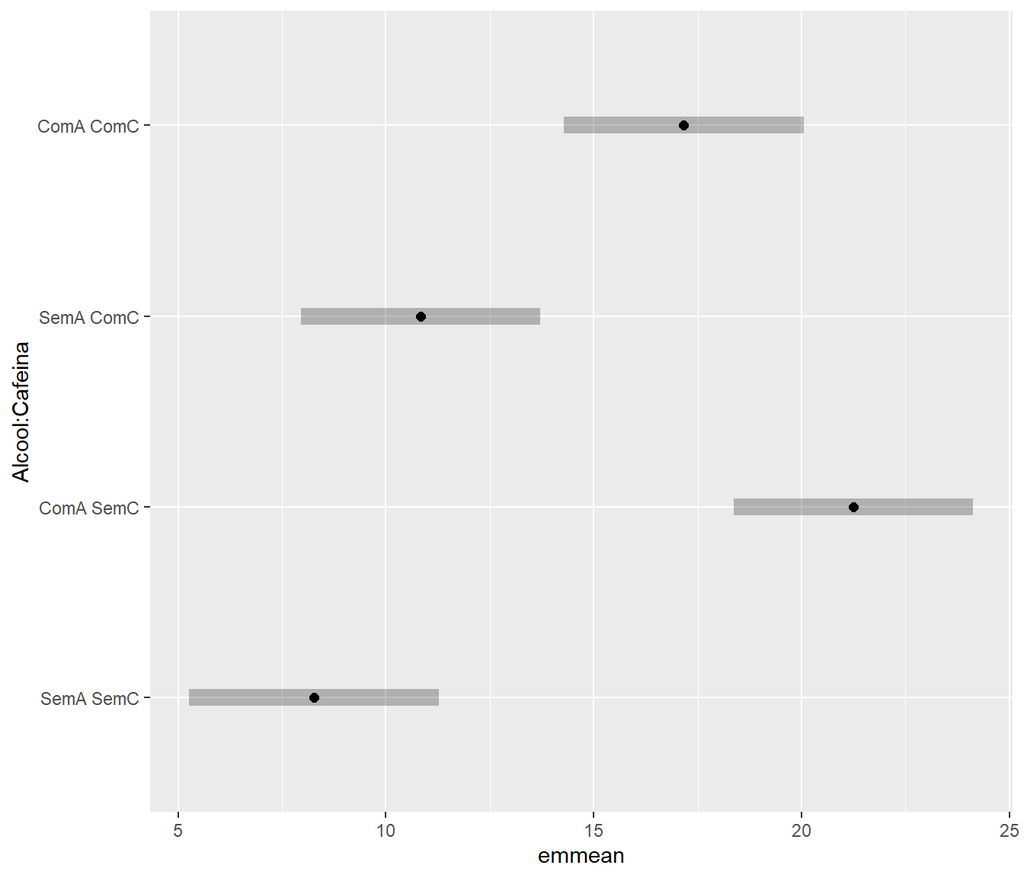

```r
print(plot(EMM.AC$emmeans,
           colors="black"))
```

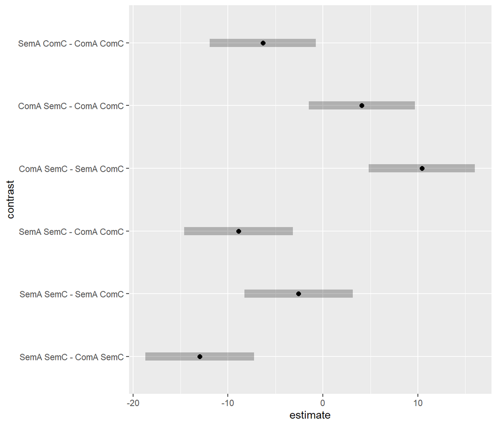

```r
print(plot(EMM.AC$contrasts,
           colors="black"))
```

```r
print(multcomp::cld(object=EMM.AC$emmeans,
                    level=1-alfa,
                    adjust="holm",
                    Letters=letters,
                    alpha=alfa))
```

```
 Alcool Cafeina emmean   SE df lower.CL upper.CL .group
 SemA   SemC      8.27 1.49 43     4.38     12.2  a
 SemA   ComC     10.83 1.43 43     7.11     14.6  a
 ComA   ComC     17.17 1.43 43    13.44     20.9   b
 ComA   SemC     21.25 1.43 43    17.52     25.0   b

Degrees-of-freedom method: satterthwaite
Confidence level used: 0.95
Conf-level adjustment: bonferroni method for 4 estimates
P value adjustment: holm method for 6 tests
significance level used: alpha = 0.05
NOTE: If two or more means share the same grouping symbol,
      then we cannot show them to be different.
      But we also did not show them to be the same.
```

```r
cat("\n\tAlcool")
```

```
    Alcool
```

```r
EMM.A <- emmeans::emmeans(modelo,
                          specs=pairwise~"Alcool",
                          adjust="holm",
                          level=1-alfa,
                          lmer.df="satterthwaite",
                          lmerTest.limit=nrow(Dados))
```

```
NOTE: Results may be misleading due to involvement in interactions
```

```r
print(summary(EMM.A$emmeans))
```

```
 Alcool emmean   SE df lower.CL upper.CL
 SemA     9.55 1.03 43     7.47     11.6
 ComA    19.21 1.01 43    17.17     21.2

Results are averaged over the levels of: Cafeina
Degrees-of-freedom method: satterthwaite
Confidence level used: 0.95
```

```r
print(summary(EMM.A$contrasts, infer=TRUE))
```

```
 contrast    estimate   SE df lower.CL upper.CL t.ratio p.value
 SemA - ComA    -9.66 1.45 43    -12.6    -6.74  -6.681  <.0001

Results are averaged over the levels of: Cafeina
Degrees-of-freedom method: satterthwaite
Confidence level used: 0.95
```

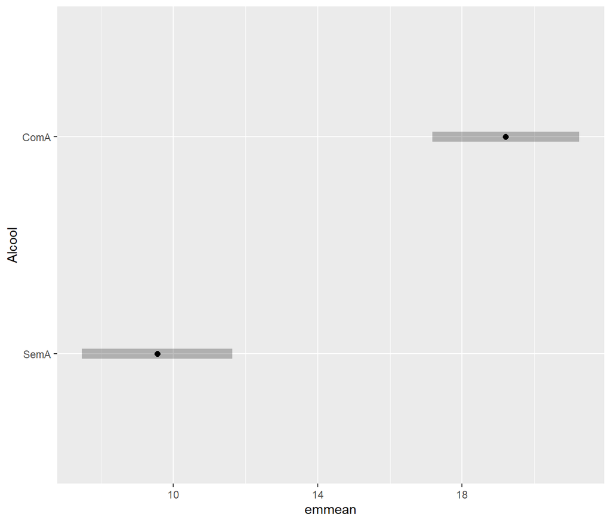

```r
print(plot(EMM.A$emmeans,
           colors="black"))
```

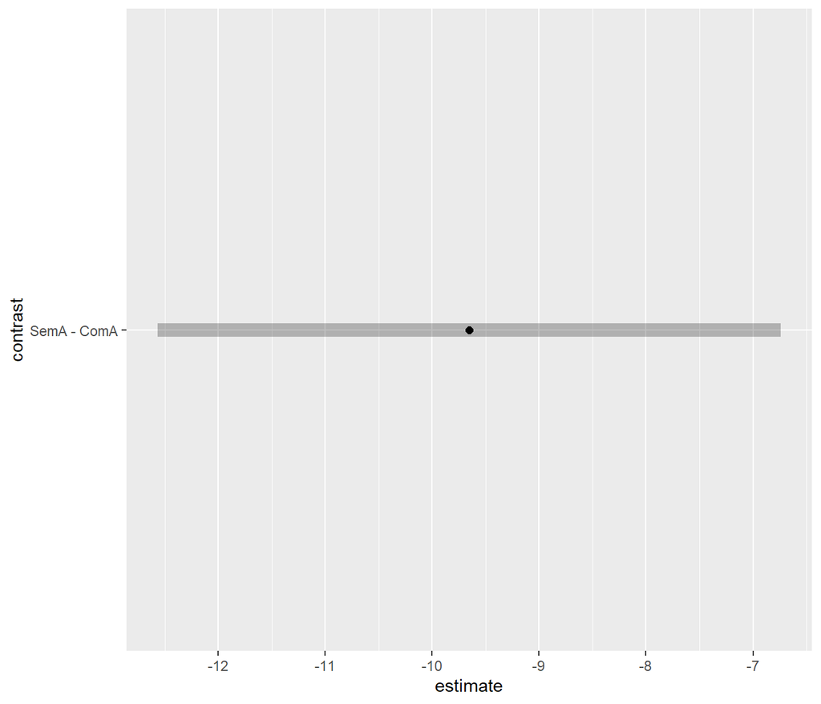

```r
print(plot(EMM.A$contrasts,
           colors="black"))
```

```r
print(multcomp::cld(object=EMM.A$emmeans,
                    level=1-alfa,
                    adjust="holm",
                    Letters=letters,
                    alpha=alfa))
```

```
 Alcool emmean   SE df lower.CL upper.CL .group
 SemA     9.55 1.03 43     7.15     12.0  a
 ComA    19.21 1.01 43    16.86     21.6   b

Results are averaged over the levels of: Cafeina
Degrees-of-freedom method: satterthwaite
Confidence level used: 0.95
Conf-level adjustment: bonferroni method for 2 estimates
significance level used: alpha = 0.05
NOTE: If two or more means share the same grouping symbol,
      then we cannot show them to be different.
      But we also did not show them to be the same.
```

```r
cat("\n\tCafeina")
```

```
    Cafeina
```

```r
EMM.C <- emmeans::emmeans(modelo,
                          specs=pairwise~"Cafeina",
                          adjust="holm",
                          level=1-alfa,
                          lmer.df="satterthwaite",
                          lmerTest.limit=nrow(Dados))
```

```
NOTE: Results may be misleading due to involvement in interactions
```

```r
print(summary(EMM.C$emmeans))
```

```
 Cafeina emmean   SE df lower.CL upper.CL
 SemC      14.8 1.03 43     12.7     16.8
 ComC      14.0 1.01 43     12.0     16.0

Results are averaged over the levels of: Alcool
Degrees-of-freedom method: satterthwaite
Confidence level used: 0.95
```

```r
print(summary(EMM.C$contrasts, infer=TRUE))
```

```
 contrast    estimate   SE df lower.CL upper.CL t.ratio p.value
 SemC - ComC    0.761 1.45 43    -2.15     3.68   0.527  0.6010

Results are averaged over the levels of: Alcool
Degrees-of-freedom method: satterthwaite
Confidence level used: 0.95
```

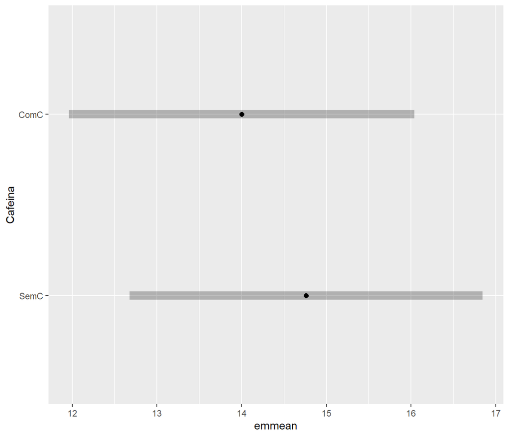

```r
print(plot(EMM.C$emmeans,
           colors="black"))
```

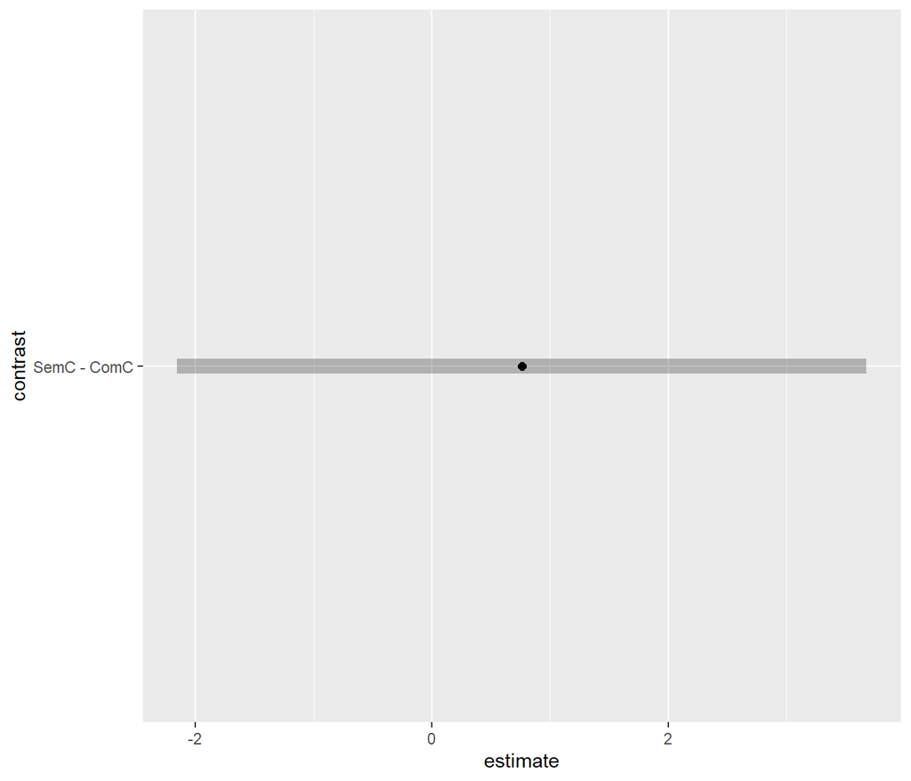

```r
print(plot(EMM.C$contrasts,
           colors="black"))
```

```r
print(multcomp::cld(object=EMM.C$emmeans,
                    level=1-alfa,
                    adjust="holm",
                    Letters=letters,
                    alpha=alfa))
```

```
 Cafeina emmean   SE df lower.CL upper.CL .group
 ComC      14.0 1.01 43     11.7     16.3  a
 SemC      14.8 1.03 43     12.4     17.2  a

Results are averaged over the levels of: Alcool
Degrees-of-freedom method: satterthwaite
Confidence level used: 0.95
Conf-level adjustment: bonferroni method for 2 estimates
significance level used: alpha = 0.05
NOTE: If two or more means share the same grouping symbol,
      then we cannot show them to be different.
      But we also did not show them to be the same.
```

**FIM**